# Project 1: What do markets like to hear?

Ken Chew (kc3040)

### Section I: Introduction

Using a quantifiable metric, the stock market indices, I tried to measure people’s reaction to what was said by the various presidents in the form of closing price. By tracking the stock prices of the various indices before and after the inaugurations from 1985, we classify speeches which are considered market friendly or not. Subsequently, we conduct various forms of data and sentiment analysis to try pick out things which “the markets like to hear”.

### Section II: Trend Analysis on Stock Market Indices

#### Examining Trump’s Inauguration

Taking President Trump as our first example, I looked at the reaction of the Dow Jones (DJIA) 15 days before and after the inauguration speech. Notice that I also added a best fit line of the before and after data points, so as to compare the gradient. Comparison of gradient is important as the stock market has momentum generally. We are interested in not only the average of clusters of closing prices before and after as it might be skewed by the ongoing trend in the market.

One interesting observation is that there is generally a change in the gradient right after inauguration speech (and this is consistent throughout all the president inauguration speeches being examined) - signaling that there is a market reaction to the speeches made by the newly minted president. In this case, we see that the gradient of DJIA increased after the speech. This is seen as a market friendly signal, and corroborates with impression that people have of his “business friendly policies”.

```r
# Abstracting relevant dates for Trump1
DonaldJTrump1.Date <- speeches_date$Date[which(speeches_date$NameTerm == "DonaldJTrump-1")]
DonaldJTrump1.DateMinus15 <- speeches_date$DateMinus15[which(speeches_date$NameTerm ==
    "DonaldJTrump-1")]
DonaldJTrump1.DatePlus15 <- speeches_date$DatePlus15[which(speeches_date$NameTerm ==
    "DonaldJTrump-1")]

DonaldJTrump1.DateMinus7 <- speeches_date$DateMinus7[which(speeches_date$NameTerm ==
    "DonaldJTrump-1")]
DonaldJTrump1.DatePlus7 <- speeches_date$DatePlus7[which(speeches_date$NameTerm ==
    "DonaldJTrump-1")]

# Subsetting stock index data to period relevant for Trump1
DonaldJTrump1.dowjones <- subset(dowjones, Date >= DonaldJTrump1.DateMinus15 &
    Date <= DonaldJTrump1.DatePlus15)
DonaldJTrump1.dowjones$Group <- DonaldJTrump1.dowjones$Date >= DonaldJTrump1.Date

DonaldJTrump1.snp500 <- subset(snp500, Date >= DonaldJTrump1.DateMinus15 & Date <=
    DonaldJTrump1.DatePlus15)
DonaldJTrump1.snp500$Group <- DonaldJTrump1.snp500$Date >= DonaldJTrump1.Date

DonaldJTrump1.nasdaq <- subset(nasdaq, Date >= DonaldJTrump1.DateMinus15 & Date <=
    DonaldJTrump1.DatePlus15)
DonaldJTrump1.nasdaq$Group <- DonaldJTrump1.nasdaq$Date >= DonaldJTrump1.Date

DonaldJTrump1.nyse <- subset(nyse, Date >= DonaldJTrump1.DateMinus15 & Date <=
    DonaldJTrump1.DatePlus15)
DonaldJTrump1.nyse$Group <- DonaldJTrump1.nyse$Date >= DonaldJTrump1.Date

DonaldJTrump1.ftse <- subset(ftse, Date >= DonaldJTrump1.DateMinus15 & Date <=
    DonaldJTrump1.DatePlus15)
DonaldJTrump1.ftse$Group <- DonaldJTrump1.ftse$Date >= DonaldJTrump1.Date

DonaldJTrump1.nikkei <- subset(nikkei, Date >= DonaldJTrump1.DateMinus15 & Date <=
    DonaldJTrump1.DatePlus15)
DonaldJTrump1.nikkei$Group <- DonaldJTrump1.nikkei$Date >= DonaldJTrump1.Date

DonaldJTrump1.hangseng <- subset(hangseng, Date >= DonaldJTrump1.DateMinus15 &
    Date <= DonaldJTrump1.DatePlus15)
DonaldJTrump1.hangseng$Group <- DonaldJTrump1.hangseng$Date >= DonaldJTrump1.Date

# Calculate DJIA gradient
DonaldJTrump1.dowjonesPreGrad15 <- lm(Close ~ Date, data = subset(DonaldJTrump1.dowjones,
    Date >= DonaldJTrump1.DateMinus15 & Date < DonaldJTrump1.Date))
DonaldJTrump1.dowjonesPostGrad15 <- lm(Close ~ Date, data = subset(DonaldJTrump1.dowjones,
    Date >= DonaldJTrump1.Date & Date <= DonaldJTrump1.DatePlus15))

DonaldJTrump1.dowjonesGradChange15 <- (coef(DonaldJTrump1.dowjonesPostGrad15)["Date"] -
    coef(DonaldJTrump1.dowjonesPreGrad15)["Date"])/abs(coef(DonaldJTrump1.dowjonesPreGrad15)["Date"])

# Calculate S&P500 gradient
DonaldJTrump1.snp500PreGrad15 <- lm(Close ~ Date, data = subset(DonaldJTrump1.snp500,
    Date >= DonaldJTrump1.DateMinus15 & Date < DonaldJTrump1.Date))
DonaldJTrump1.snp500PostGrad15 <- lm(Close ~ Date, data = subset(DonaldJTrump1.snp500,
    Date >= DonaldJTrump1.Date & Date <= DonaldJTrump1.DatePlus15))

DonaldJTrump1.snp500GradChange15 <- (coef(DonaldJTrump1.snp500PostGrad15)["Date"] -
    coef(DonaldJTrump1.snp500PreGrad15)["Date"])/abs(coef(DonaldJTrump1.snp500PreGrad15)["Date"])

# Calculate Nasdaq gradient
DonaldJTrump1.nasdaqPreGrad15 <- lm(Close ~ Date, data = subset(DonaldJTrump1.nasdaq,
    Date >= DonaldJTrump1.DateMinus15 & Date < DonaldJTrump1.Date))
DonaldJTrump1.nasdaqPostGrad15 <- lm(Close ~ Date, data = subset(DonaldJTrump1.nasdaq,
    Date >= DonaldJTrump1.Date & Date <= DonaldJTrump1.DatePlus15))

DonaldJTrump1.nasdaqGradChange15 <- (coef(DonaldJTrump1.nasdaqPostGrad15)["Date"] -
    coef(DonaldJTrump1.nasdaqPreGrad15)["Date"])/abs(coef(DonaldJTrump1.nasdaqPreGrad15)["Date"])

# Calculate NYSE gradient
DonaldJTrump1.nysePreGrad15 <- lm(Close ~ Date, data = subset(DonaldJTrump1.nyse,
    Date >= DonaldJTrump1.DateMinus15 & Date < DonaldJTrump1.Date))
DonaldJTrump1.nysePostGrad15 <- lm(Close ~ Date, data = subset(DonaldJTrump1.nyse,
    Date >= DonaldJTrump1.Date & Date <= DonaldJTrump1.DatePlus15))

DonaldJTrump1.nyseGradChange15 <- (coef(DonaldJTrump1.nysePostGrad15)["Date"] -
    coef(DonaldJTrump1.nysePreGrad15)["Date"])/abs(coef(DonaldJTrump1.nysePreGrad15)["Date"])

# Calculate FTSE gradient
DonaldJTrump1.ftsePreGrad15 <- lm(Close ~ Date, data = subset(DonaldJTrump1.ftse,
    Date >= DonaldJTrump1.DateMinus15 & Date < DonaldJTrump1.Date))
DonaldJTrump1.ftsePostGrad15 <- lm(Close ~ Date, data = subset(DonaldJTrump1.ftse,
    Date >= DonaldJTrump1.Date & Date <= DonaldJTrump1.DatePlus15))

DonaldJTrump1.ftseGradChange15 <- (coef(DonaldJTrump1.ftsePostGrad15)["Date"] -
    coef(DonaldJTrump1.ftsePreGrad15)["Date"])/abs(coef(DonaldJTrump1.ftsePreGrad15)["Date"])

# Calculate Hang Seng gradient
DonaldJTrump1.hangsengPreGrad15 <- lm(Close ~ Date, data = subset(DonaldJTrump1.hangseng,
    Date >= DonaldJTrump1.DateMinus15 & Date < DonaldJTrump1.Date))
DonaldJTrump1.hangsengPostGrad15 <- lm(Close ~ Date, data = subset(DonaldJTrump1.hangseng,
    Date >= DonaldJTrump1.Date & Date <= DonaldJTrump1.DatePlus15))

DonaldJTrump1.hangsengGradChange15 <- (coef(DonaldJTrump1.hangsengPostGrad15)["Date"] -
    coef(DonaldJTrump1.hangsengPreGrad15)["Date"])/abs(coef(DonaldJTrump1.hangsengPreGrad15)["Date"])

# Calculate Nikkei gradient
DonaldJTrump1.nikkeiPreGrad15 <- lm(Close ~ Date, data = subset(DonaldJTrump1.nikkei,
    Date >= DonaldJTrump1.DateMinus15 & Date < DonaldJTrump1.Date))
DonaldJTrump1.nikkeiPostGrad15 <- lm(Close ~ Date, data = subset(DonaldJTrump1.nikkei,
    Date >= DonaldJTrump1.Date & Date <= DonaldJTrump1.DatePlus15))

DonaldJTrump1.nikkeiGradChange15 <- (coef(DonaldJTrump1.nikkeiPostGrad15)["Date"] -
    coef(DonaldJTrump1.nikkeiPreGrad15)["Date"])/abs(coef(DonaldJTrump1.nikkeiPreGrad15)["Date"])

# Plot Trump1 DJIA +- 15 days after inauguration
DonaldJTrump1.dowjones.plot <- ggplot(DonaldJTrump1.dowjones[which(DonaldJTrump1.dowjones$Date >=
    (DonaldJTrump1.Date - 15) & DonaldJTrump1.dowjones$Date <= (DonaldJTrump1.Date +
    15)), ], aes(x = Date, y = Close)) + geom_point(size = 4, aes(color = Group)) +
    ylab("Closing Price") + ggtitle("DJIA pre/post Trump1 Inauguration") + geom_smooth(data = subset(DonaldJTrump1.dowjones,
    Group == 0 | Group == 1), aes(x = Date, y = Close, color = factor(Group)),
    method = lm, se = F) + scale_x_date(date_breaks = "3 days", date_minor_breaks = "1 day",
    date_labels = "%b%d") + theme(legend.position = "none", plot.title = element_text(hjust = 0.5,
    size = 20), axis.text.x = element_text(colour = "grey20", size = 11, angle = 0,
    hjust = 0.5, vjust = 0.5, face = "plain"), axis.text.y = element_text(colour = "grey20",
    size = 14, angle = 0, hjust = 1, vjust = 0, face = "plain"), axis.title.x = element_text(colour = "grey20",
    size = 16, angle = 0, hjust = 0.5, vjust = 0, face = "plain"), axis.title.y = element_text(colour = "grey20",
    size = 16, angle = 90, hjust = 0.5, vjust = 0.5, face = "plain")) + geom_vline(xintercept = as.numeric(DonaldJTrump1.Date),
    col = "black", size = 1, linetype = 4)
```

```r
# Plot Trump1 SNP500 +- 15 days after inauguration
DonaldJTrump1.snp500.plot <- ggplot(DonaldJTrump1.snp500[which(DonaldJTrump1.snp500$Date >=
    (DonaldJTrump1.Date - 15) & DonaldJTrump1.snp500$Date <= (DonaldJTrump1.Date +
    15)), ], aes(x = Date, y = Close)) + geom_point(size = 4, aes(color = Group)) +
    ylab("Closing Price") + ggtitle("S&P500 pre/post Trump1 Inauguration") +
    geom_smooth(data = subset(DonaldJTrump1.snp500, Group == 0 | Group == 1),
        aes(x = Date, y = Close, color = factor(Group)), method = lm, se = F) +
    scale_x_date(date_breaks = "3 days", date_minor_breaks = "1 day", date_labels = "%b%d") +
    theme(legend.position = "none", plot.title = element_text(hjust = 0.5, size = 20),
        axis.text.x = element_text(colour = "grey20", size = 11, angle = 0,
            hjust = 0.5, vjust = 0.5, face = "plain"), axis.text.y = element_text(colour = "grey20",
            size = 14, angle = 0, hjust = 1, vjust = 0, face = "plain"), axis.title.x = element_text(colour = "grey20",
            size = 16, angle = 0, hjust = 0.5, vjust = 0, face = "plain"), axis.title.y = element_text(colour = "grey20",
            size = 16, angle = 90, hjust = 0.5, vjust = 0.5, face = "plain")) +
    geom_vline(xintercept = as.numeric(DonaldJTrump1.Date), col = "black", size = 1,
        linetype = 4)

# Plot Trump1 nasdaq +- 15 days after inauguration
DonaldJTrump1.nasdaq.plot <- ggplot(DonaldJTrump1.nasdaq[which(DonaldJTrump1.nasdaq$Date >=
    (DonaldJTrump1.Date - 15) & DonaldJTrump1.nasdaq$Date <= (DonaldJTrump1.Date +
    15)), ], aes(x = Date, y = Close)) + geom_point(size = 4, aes(color = Group)) +
    ylab("Closing Price") + ggtitle("Nasdaq pre/post Trump1 Inauguration") +
    geom_smooth(data = subset(DonaldJTrump1.nasdaq, Group == 0 | Group == 1),
        aes(x = Date, y = Close, color = factor(Group)), method = lm, se = F) +
    scale_x_date(date_breaks = "3 days", date_minor_breaks = "1 day", date_labels = "%b%d") +
    theme(legend.position = "none", plot.title = element_text(hjust = 0.5, size = 20),
        axis.text.x = element_text(colour = "grey20", size = 11, angle = 0,
            hjust = 0.5, vjust = 0.5, face = "plain"), axis.text.y = element_text(colour = "grey20",
            size = 14, angle = 0, hjust = 1, vjust = 0, face = "plain"), axis.title.x = element_text(colour = "grey20",
            size = 16, angle = 0, hjust = 0.5, vjust = 0, face = "plain"), axis.title.y = element_text(colour = "grey20",
            size = 16, angle = 90, hjust = 0.5, vjust = 0.5, face = "plain")) +
    geom_vline(xintercept = as.numeric(DonaldJTrump1.Date), col = "black", size = 1,
        linetype = 4)

# Plot Trump1 NYSE +- 15 days after inauguration
DonaldJTrump1.nyse.plot <- ggplot(DonaldJTrump1.nyse[which(DonaldJTrump1.nyse$Date >=
    (DonaldJTrump1.Date - 15) & DonaldJTrump1.nyse$Date <= (DonaldJTrump1.Date +
    15)), ], aes(x = Date, y = Close)) + geom_point(size = 4, aes(color = Group)) +
    ylab("Closing Price") + ggtitle("NYSE pre/post Trump1 Inauguration") + geom_smooth(data = subset(DonaldJTrump1.nyse,
    Group == 0 | Group == 1), aes(x = Date, y = Close, color = factor(Group)),
    method = lm, se = F) + scale_x_date(date_breaks = "3 days", date_minor_breaks = "1 day",
    date_labels = "%b%d") + theme(legend.position = "none", plot.title = element_text(hjust = 0.5,
    size = 20), axis.text.x = element_text(colour = "grey20", size = 11, angle = 0,
    hjust = 0.5, vjust = 0.5, face = "plain"), axis.text.y = element_text(colour = "grey20",
    size = 14, angle = 0, hjust = 1, vjust = 0, face = "plain"), axis.title.x = element_text(colour = "grey20",
    size = 16, angle = 0, hjust = 0.5, vjust = 0, face = "plain"), axis.title.y = element_text(colour = "grey20",
    size = 16, angle = 90, hjust = 0.5, vjust = 0.5, face = "plain")) + geom_vline(xintercept = as.numeric(DonaldJTrump1.Date),
    col = "black", size = 1, linetype = 4)

# Plot Trump1 FTSE +- 15 days after inauguration
DonaldJTrump1.ftse.plot <- ggplot(DonaldJTrump1.ftse[which(DonaldJTrump1.ftse$Date >=
    (DonaldJTrump1.Date - 15) & DonaldJTrump1.ftse$Date <= (DonaldJTrump1.Date +
    15)), ], aes(x = Date, y = Close)) + geom_point(size = 4, aes(color = Group)) +
    ylab("Closing Price") + ggtitle("FTSE pre/post Trump1 Inauguration") + geom_smooth(data = subset(DonaldJTrump1.ftse,
    Group == 0 | Group == 1), aes(x = Date, y = Close, color = factor(Group)),
    method = lm, se = F) + scale_x_date(date_breaks = "3 days", date_minor_breaks = "1 day",
    date_labels = "%b%d") + theme(legend.position = "none", plot.title = element_text(hjust = 0.5,
    size = 20), axis.text.x = element_text(colour = "grey20", size = 11, angle = 0,
    hjust = 0.5, vjust = 0.5, face = "plain"), axis.text.y = element_text(colour = "grey20",
    size = 14, angle = 0, hjust = 1, vjust = 0, face = "plain"), axis.title.x = element_text(colour = "grey20",
    size = 16, angle = 0, hjust = 0.5, vjust = 0, face = "plain"), axis.title.y = element_text(colour = "grey20",
    size = 16, angle = 90, hjust = 0.5, vjust = 0.5, face = "plain")) + geom_vline(xintercept = as.numeric(DonaldJTrump1.Date),
    col = "black", size = 1, linetype = 4)

# Plot Trump1 Nikkei +- 15 days after inauguration
DonaldJTrump1.nikkei.plot <- ggplot(DonaldJTrump1.nikkei[which(DonaldJTrump1.nikkei$Date >=
    (DonaldJTrump1.Date - 15) & DonaldJTrump1.nikkei$Date <= (DonaldJTrump1.Date +
    15)), ], aes(x = Date, y = Close)) + geom_point(size = 4, aes(color = Group)) +
    ylab("Closing Price") + ggtitle("Nikkei pre/post Trump1 Inauguration") +
    geom_smooth(data = subset(DonaldJTrump1.nikkei, Group == 0 | Group == 1),
        aes(x = Date, y = Close, color = factor(Group)), method = lm, se = F) +
    scale_x_date(date_breaks = "3 days", date_minor_breaks = "1 day", date_labels = "%b%d") +
    theme(legend.position = "none", plot.title = element_text(hjust = 0.5, size = 20),
        axis.text.x = element_text(colour = "grey20", size = 11, angle = 0,
            hjust = 0.5, vjust = 0.5, face = "plain"), axis.text.y = element_text(colour = "grey20",
            size = 14, angle = 0, hjust = 1, vjust = 0, face = "plain"), axis.title.x = element_text(colour = "grey20",
            size = 16, angle = 0, hjust = 0.5, vjust = 0, face = "plain"), axis.title.y = element_text(colour = "grey20",
            size = 16, angle = 90, hjust = 0.5, vjust = 0.5, face = "plain")) +
    geom_vline(xintercept = as.numeric(DonaldJTrump1.Date), col = "black", size = 1,
        linetype = 4)
```

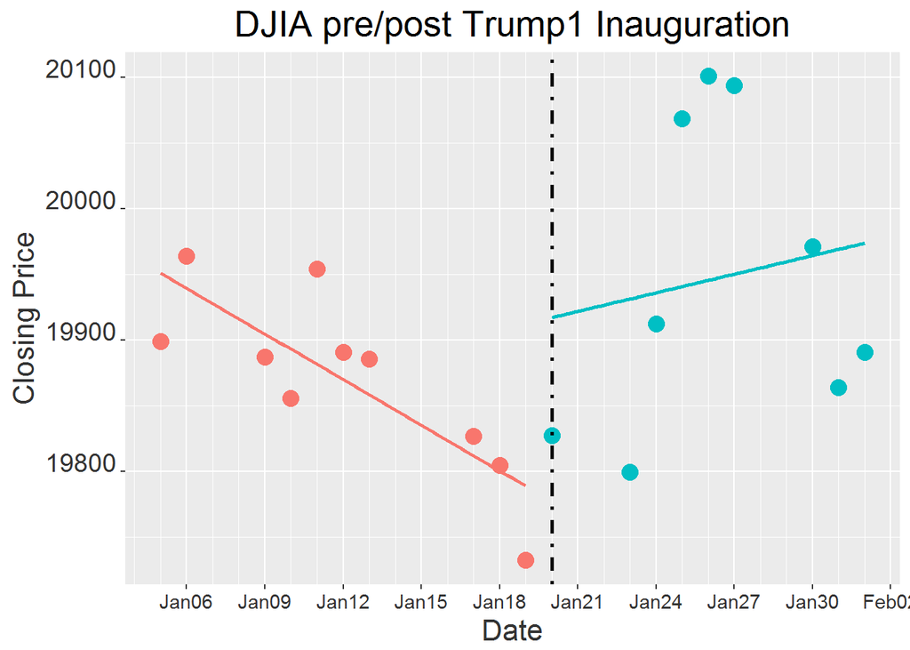

```r
# Plot Trump1 Hangseng +- 15 days after inauguration
DonaldJTrump1.hangseng.plot <- ggplot(DonaldJTrump1.hangseng[which(DonaldJTrump1.hangseng$Date >=
    (DonaldJTrump1.Date - 15) & DonaldJTrump1.hangseng$Date <= (DonaldJTrump1.Date +
    15)), ], aes(x = Date, y = Close)) + geom_point(size = 4, aes(color = Group)) +
    ylab("Closing Price") + ggtitle("Hangseng pre/post Trump1 Inauguration") +
    geom_smooth(data = subset(DonaldJTrump1.hangseng, Group == 0 | Group ==
        1), aes(x = Date, y = Close, color = factor(Group)), method = lm, se = F) +
    scale_x_date(date_breaks = "3 days", date_minor_breaks = "1 day", date_labels = "%b%d") +
    theme(legend.position = "none", plot.title = element_text(hjust = 0.5, size = 20),
        axis.text.x = element_text(colour = "grey20", size = 11, angle = 0,
            hjust = 0.5, vjust = 0.5, face = "plain"), axis.text.y = element_text(colour = "grey20",
            size = 14, angle = 0, hjust = 1, vjust = 0, face = "plain"), axis.title.x = element_text(colour = "grey20",
            size = 16, angle = 0, hjust = 0.5, vjust = 0, face = "plain"), axis.title.y = element_text(colour = "grey20",
            size = 16, angle = 90, hjust = 0.5, vjust = 0.5, face = "plain")) +
    geom_vline(xintercept = as.numeric(DonaldJTrump1.Date), col = "black", size = 1,
        linetype = 4)

DonaldJTrump1.dowjones.plot
```

To ensure that we are not looking at only 1 index and making premature conclusions, I thus did the same analysis on all other major indices: S&P500, Nasdaq, NYSE. Of course, major indices are not limited to only the US ones, and thus I did the same for the FTSE, Hang Seng and Nikkei indices to get a good geographical spread across the continents.

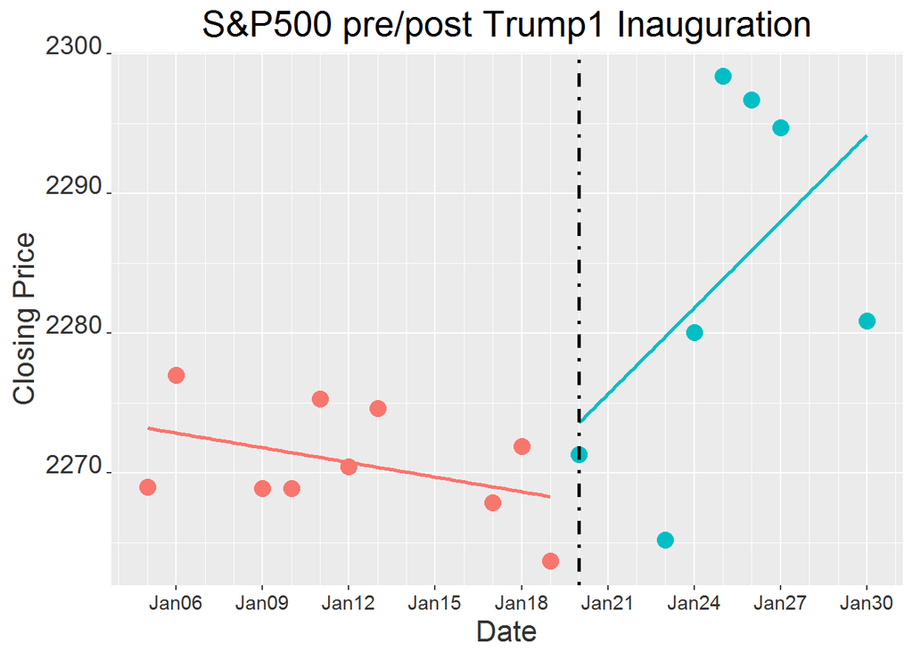

```r
DonaldJTrump1.snp500.plot
```

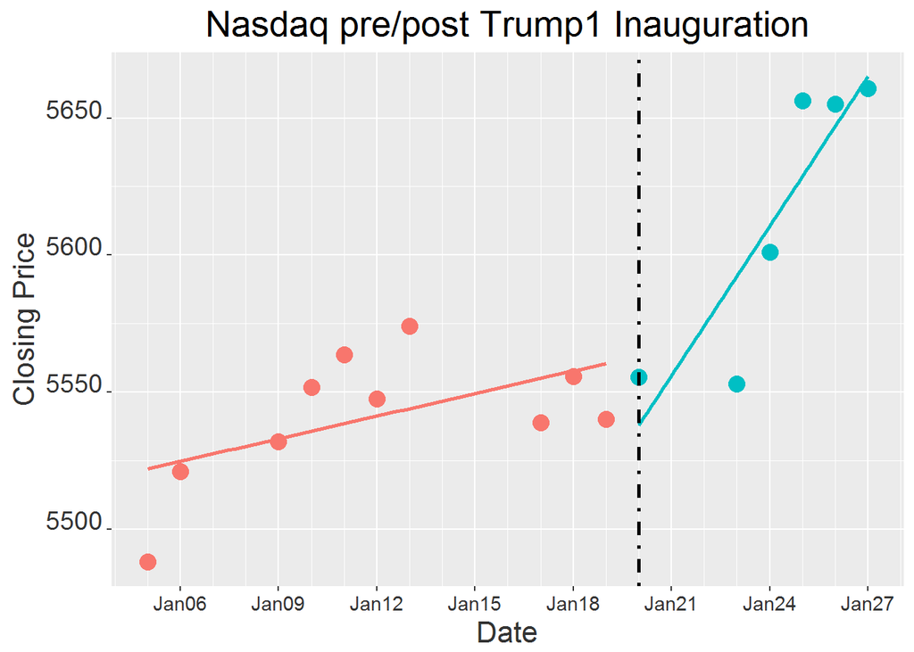

```r
DonaldJTrump1.nasdaq.plot
```

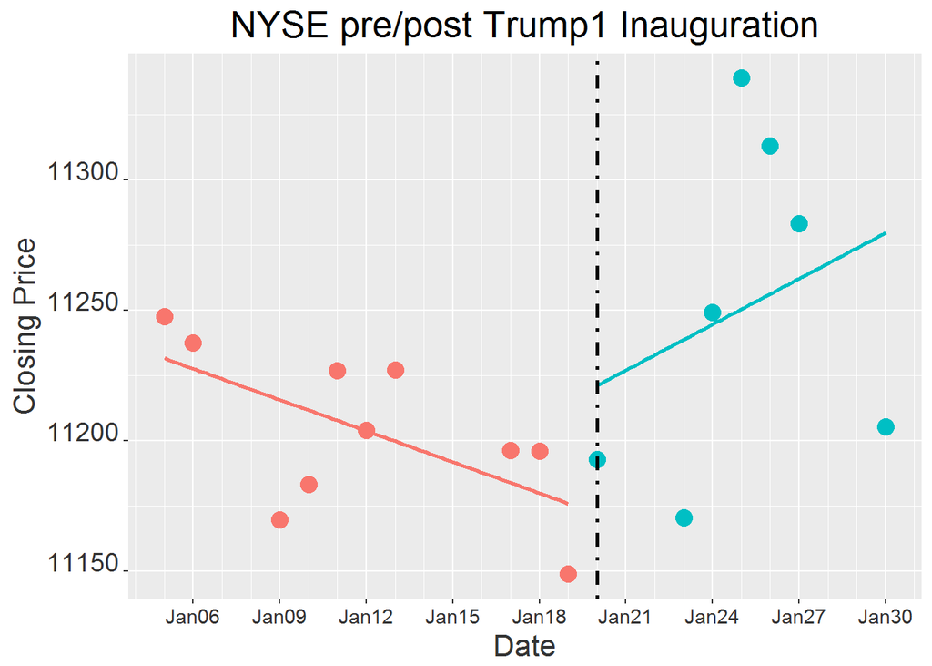

```r
DonaldJTrump1.nyse.plot
```

We see from the charts that the directionality of change amongst US indices is consistent - which means most US investors think that Trump’s inauguration speech gave them optimism.

The Asian indices also followed the trend of the US markets: the Hang Seng and Nikkei rose after President Trumps speech. This was a little perplexing. Initially, I hypothesized that the Asian markets would react negatively to President Trump’s speech because he axed the TPP, but this was not the case.

The UK index result was however in contrary to the US market. The FTSE trend actually turned negative after the speech. That is something which is interesting to look into given that the UK is trying to build closer trade ties with the US after Brexit.

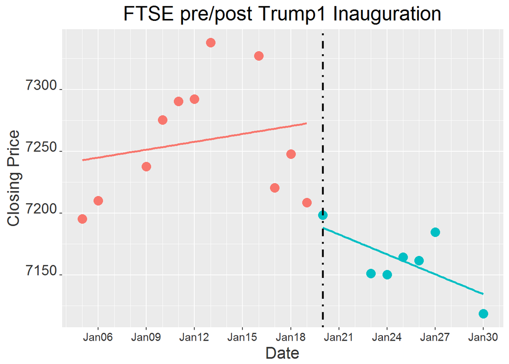

```r
DonaldJTrump1.ftse.plot
```

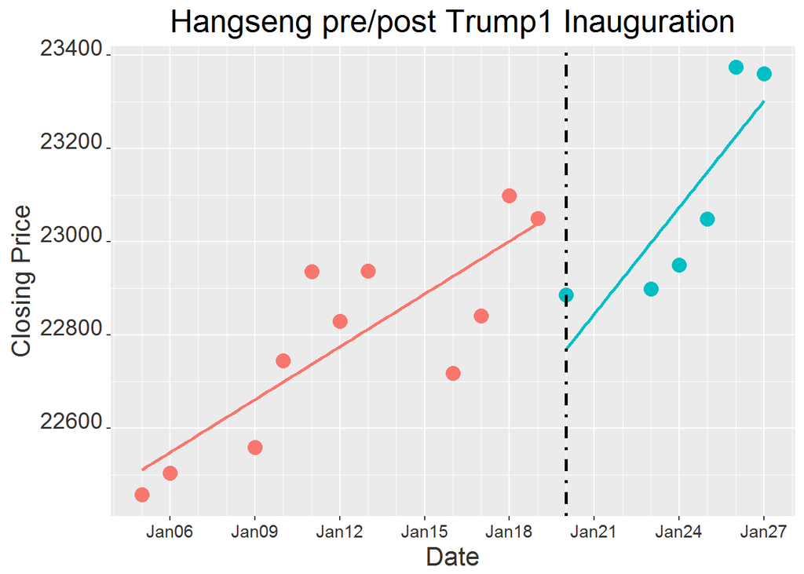

```r
DonaldJTrump1.hangseng.plot
```

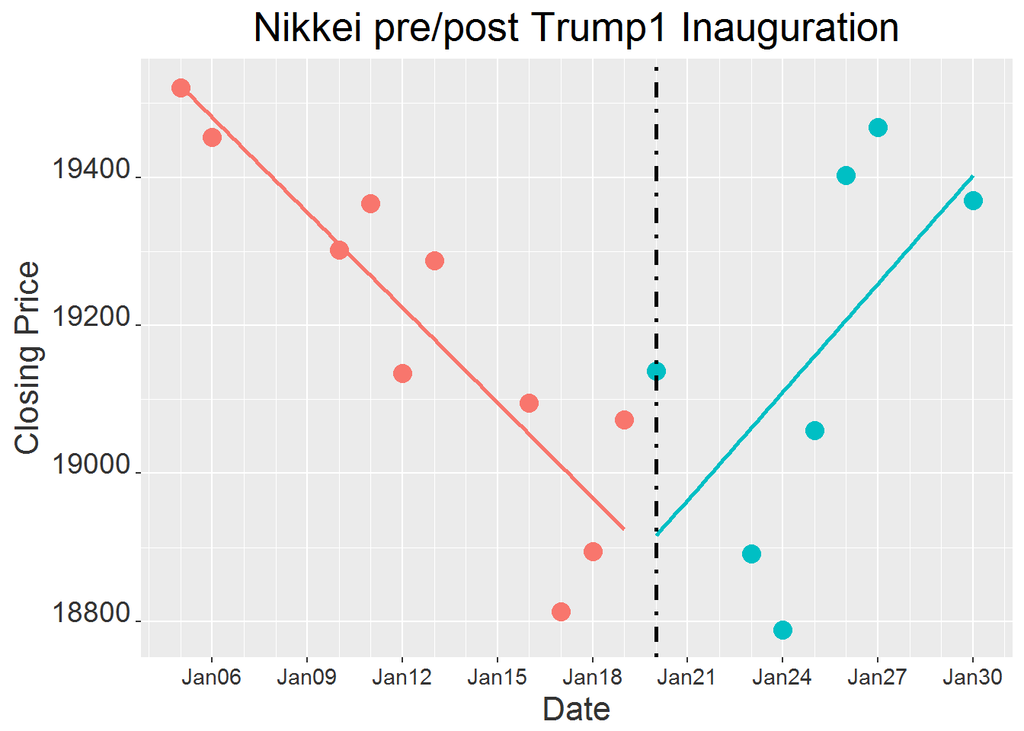

```r
DonaldJTrump1.nikkei.plot
```

```r
# All Gradient Changes
DonaldJTrump1.GradChangeVec <- c(DonaldJTrump1.dowjonesGradChange15, DonaldJTrump1.snp500GradChange15,
    DonaldJTrump1.nasdaqGradChange15, DonaldJTrump1.nyseGradChange15, DonaldJTrump1.ftseGradChange15,
    DonaldJTrump1.hangsengGradChange15, DonaldJTrump1.nikkeiGradChange15)
IndicesNames <- c("Dow Jones", "S&P500", "Nasdaq", "NYSE", "FTSE", "Hang Seng",
    "Nikkei")

DonaldJTrump1.GradChangeDF <- data.frame(President = c("DonaldJTrump-1", "",
    "", "", "", "", ""), id = 1:7, Index = IndicesNames, GradChange = percent(DonaldJTrump1.GradChangeVec))


formattable(DonaldJTrump1.GradChangeDF, align = "c", list(President = formatter("span",
    style = x ~ ifelse(x == "DonaldJTrump-1", style(font.weight = "bold"), NA)),
    GradChange = formatter("span", style = x ~ style(color = ifelse(x < 0, "red",
        "green")), x ~ icontext(ifelse(x < 0, "arrow-down", "arrow-up"), x))))
```

| President | id | Index | GradChange |
| --- | --- | --- | --- |
| DonaldJTrump-1 | 1 | Dow Jones | 140.84% |
|  | 2 | S&P500 | 688.75% |
|  | 3 | Nasdaq | 561.80% |
|  | 4 | NYSE | 247.19% |
|  | 5 | FTSE | -352.65% |
|  | 6 | Hang Seng | 101.81% |
|  | 7 | Nikkei | 213.66% |

Conducting the same analysis for all the Presidents, we summarize the results in the following tables showing the change in gradient after the inauguration speeches. From these tables, we categorize the inauguration speeches into those which are market lifting and market dampening.

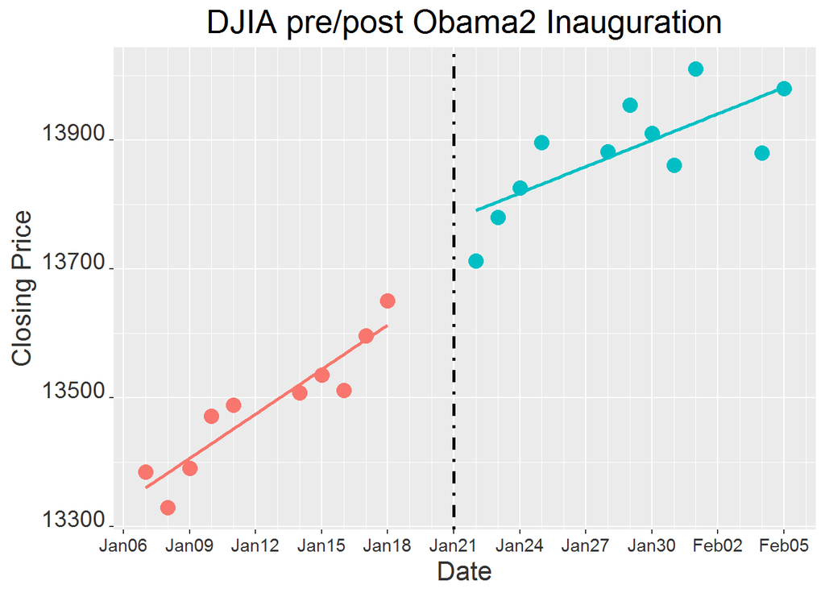

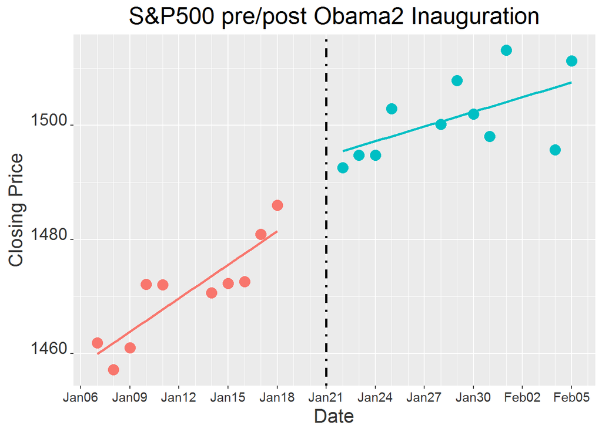

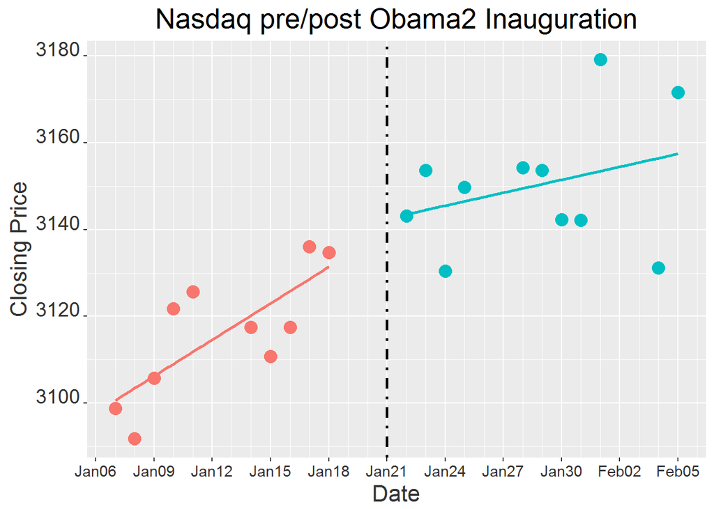

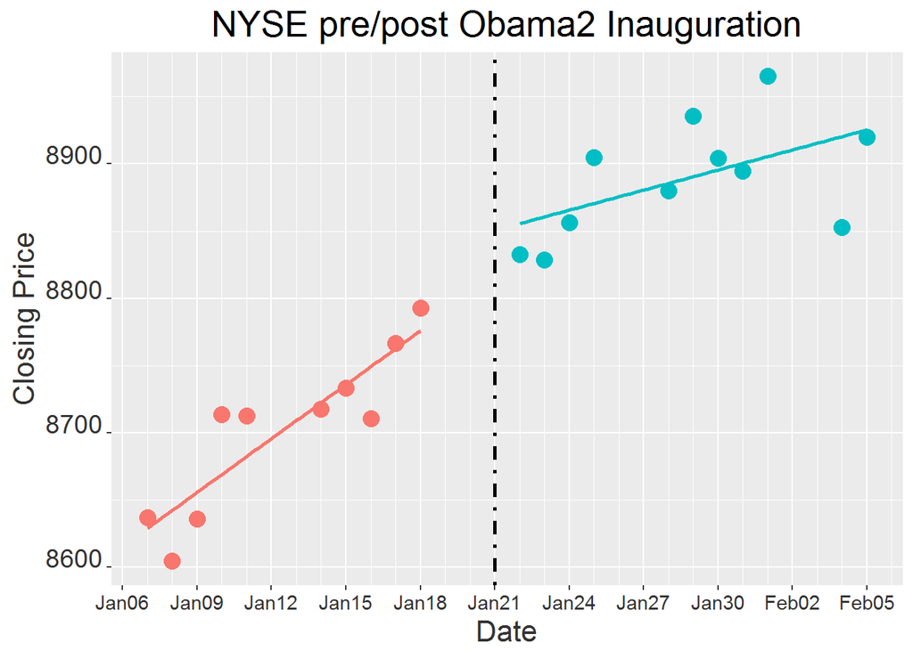

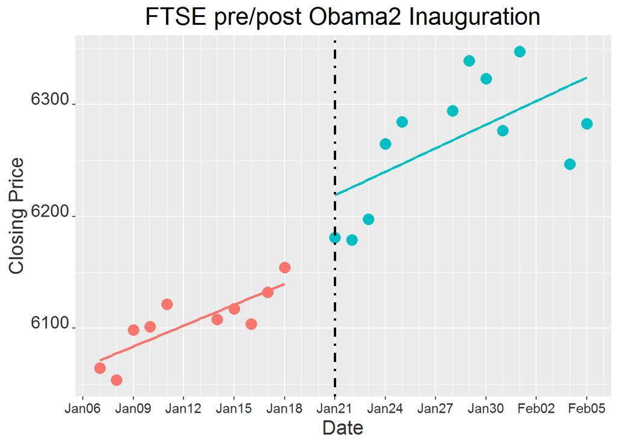

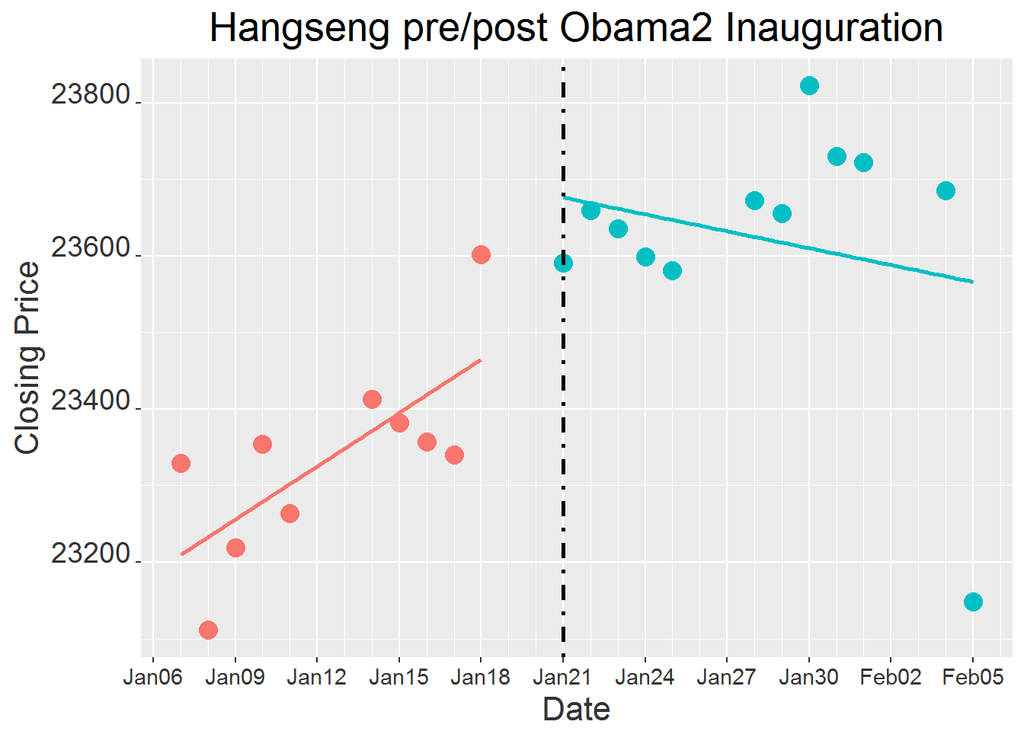

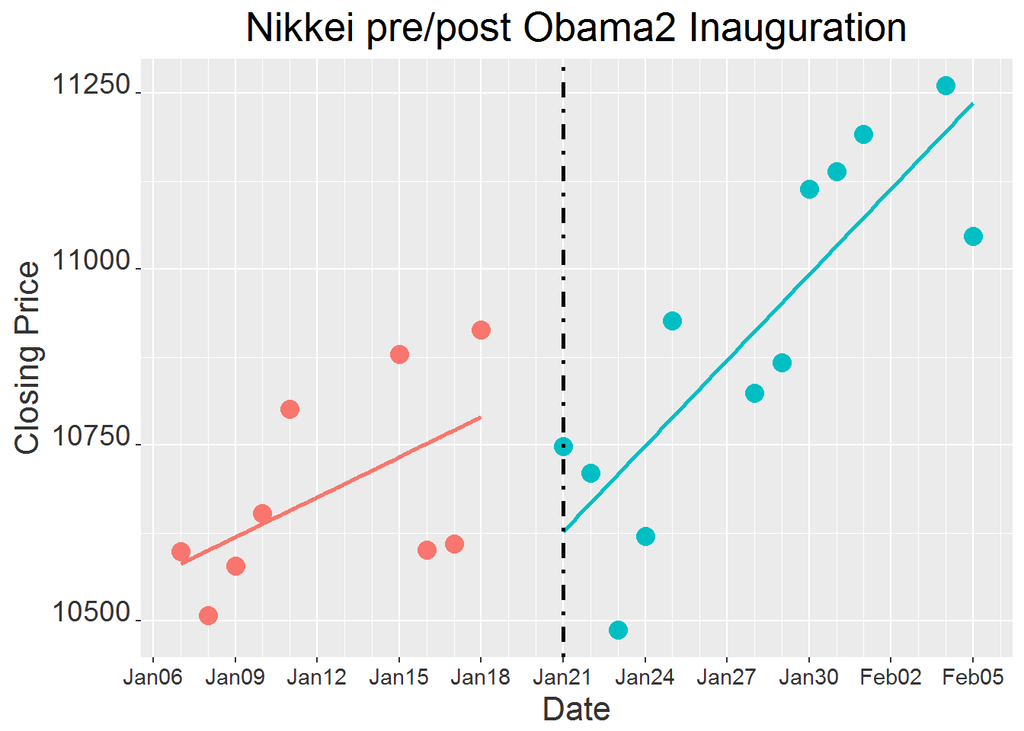

| President | id | Index | GradChange |
| --- | --- | --- | --- |
| BarackObama-2 | 1 | Dow Jones | -40.54% |
|  | 2 | S&P500 | -56.06% |
|  | 3 | Nasdaq | -64.41% |
|  | 4 | NYSE | -62.68% |
|  | 5 | FTSE | 12.94% |
|  | 6 | Hang Seng | -131.74% |
|  | 7 | Nikkei | 114.42% |

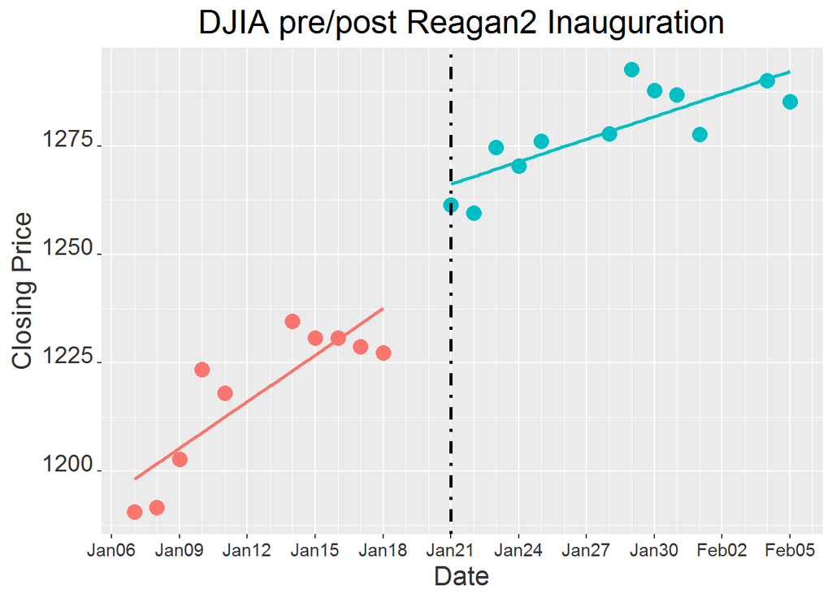

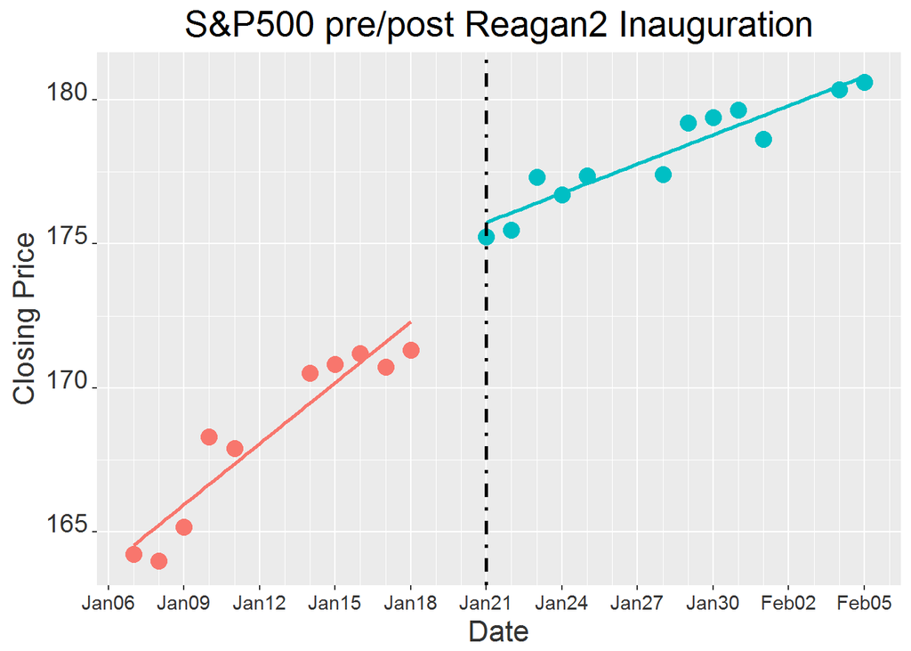

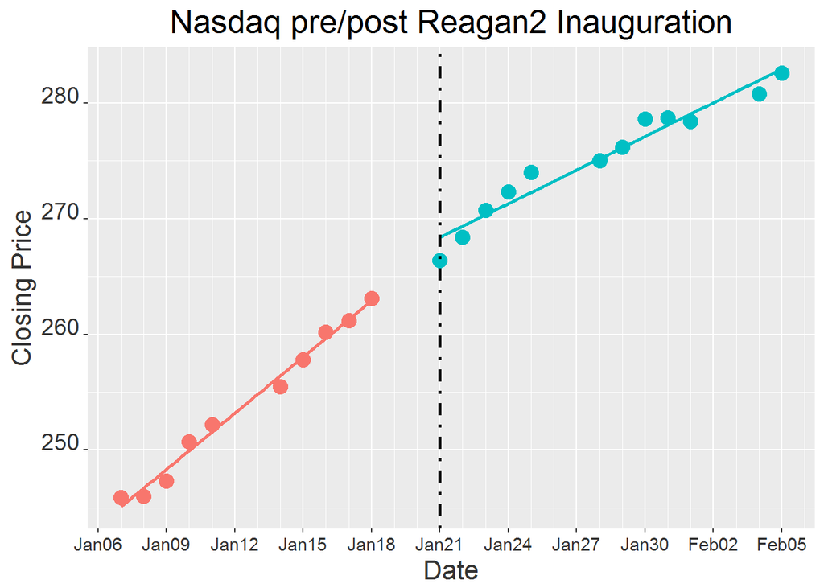

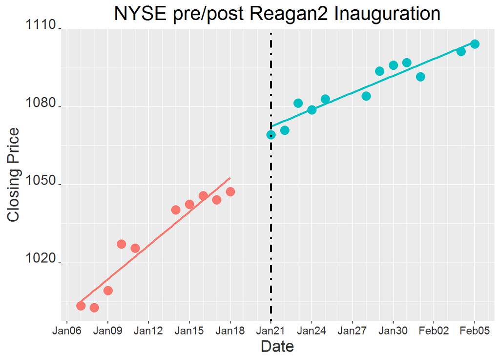

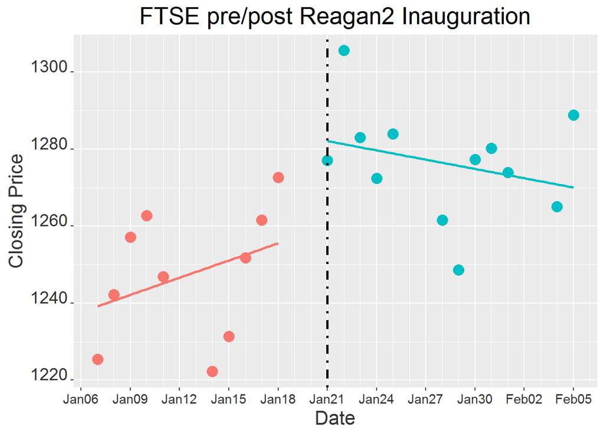

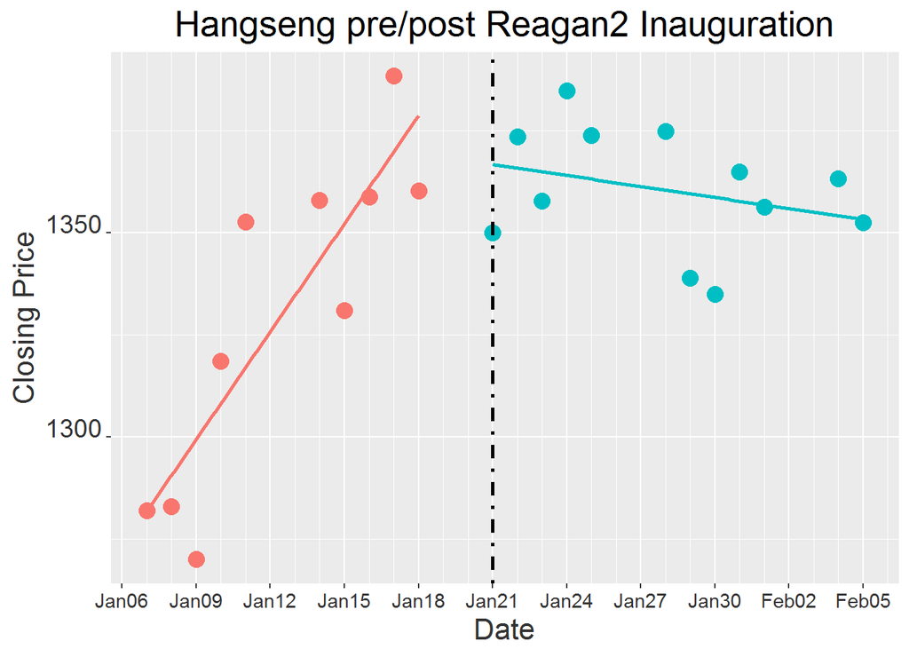

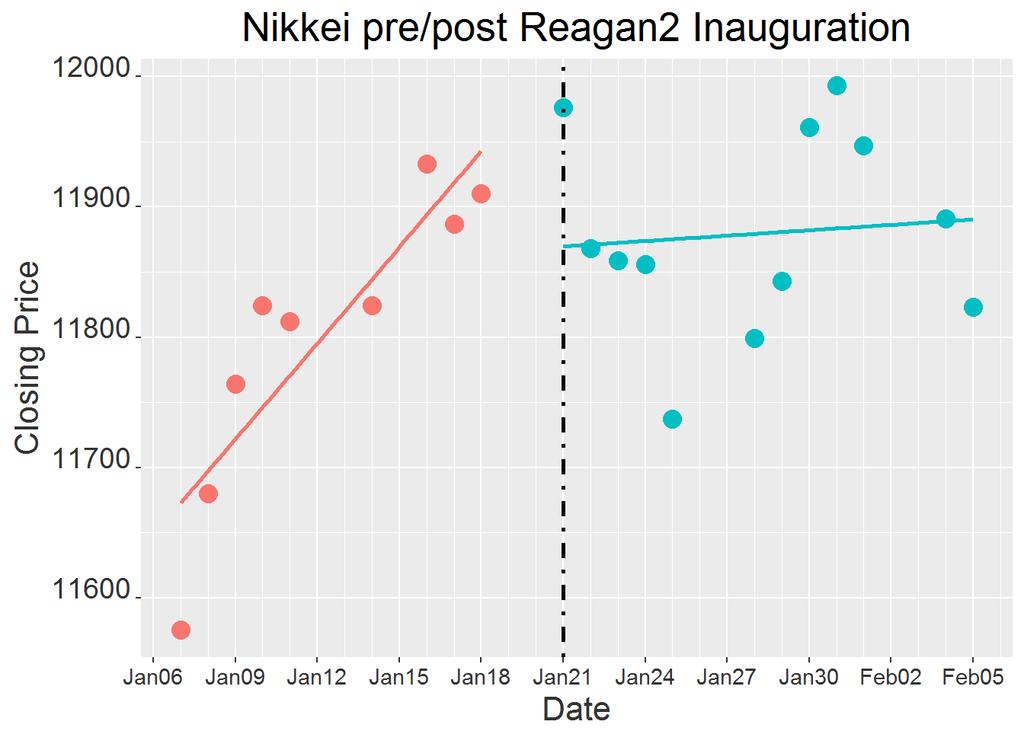

| President | id | Index | GradChange |
| --- | --- | --- | --- |
| RonaldReagan-2 | 1 | Dow Jones | -51.51% |
|  | 2 | S&P500 | -52.13% |
|  | 3 | Nasdaq | -40.14% |
|  | 4 | NYSE | -49.87% |
|  | 5 | FTSE | -154.06% |
|  | 6 | Hang Seng | -110.23% |
|  | 7 | Nikkei | -94.39% |

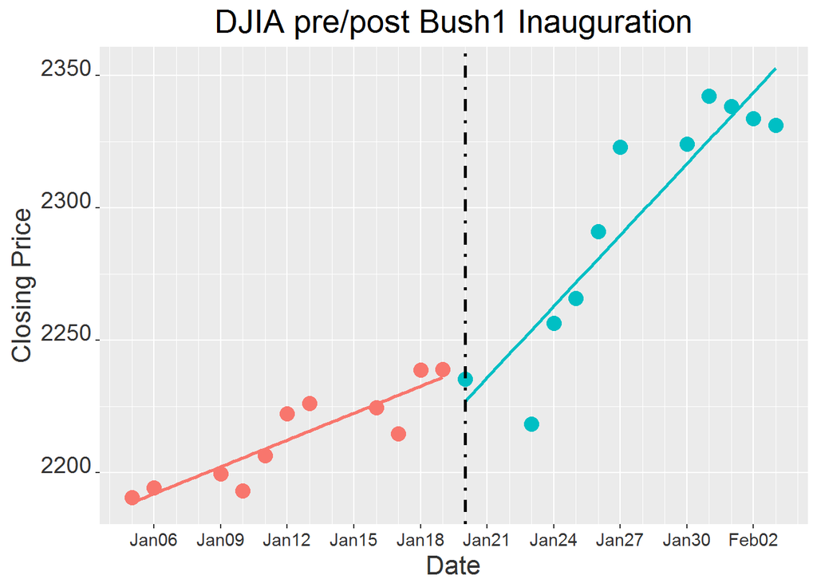

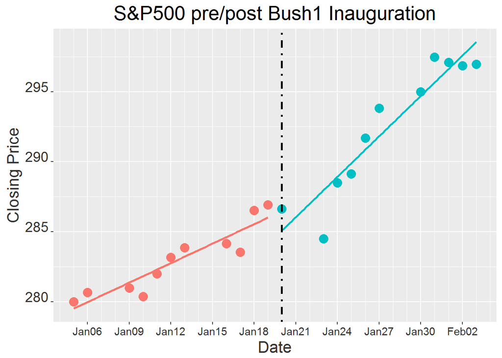

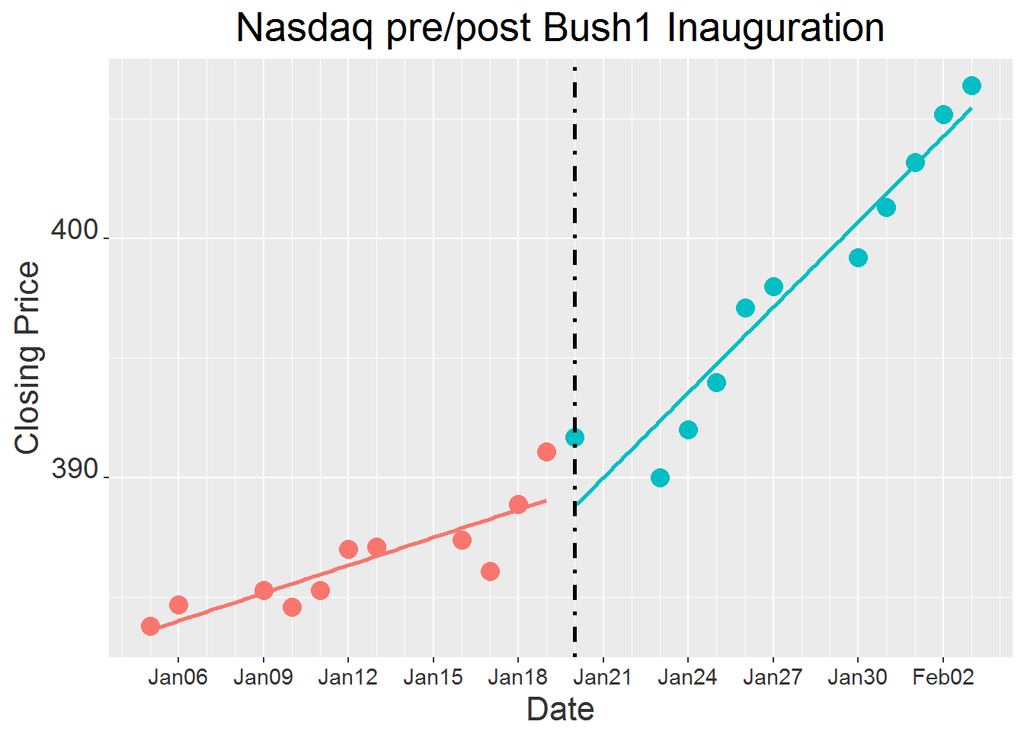

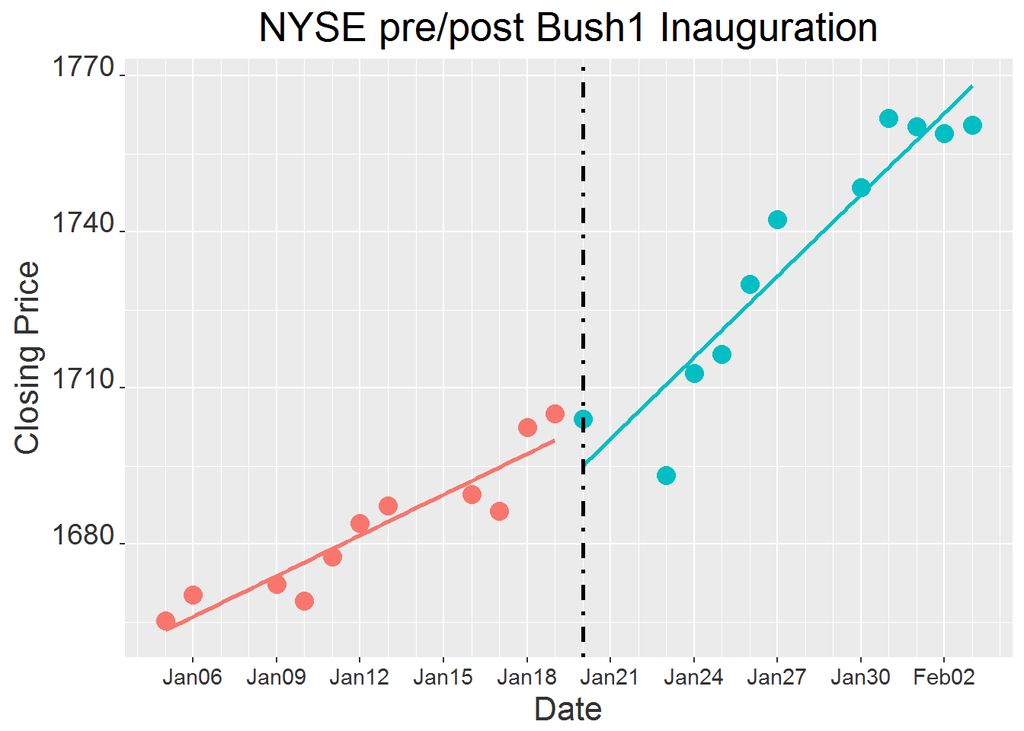

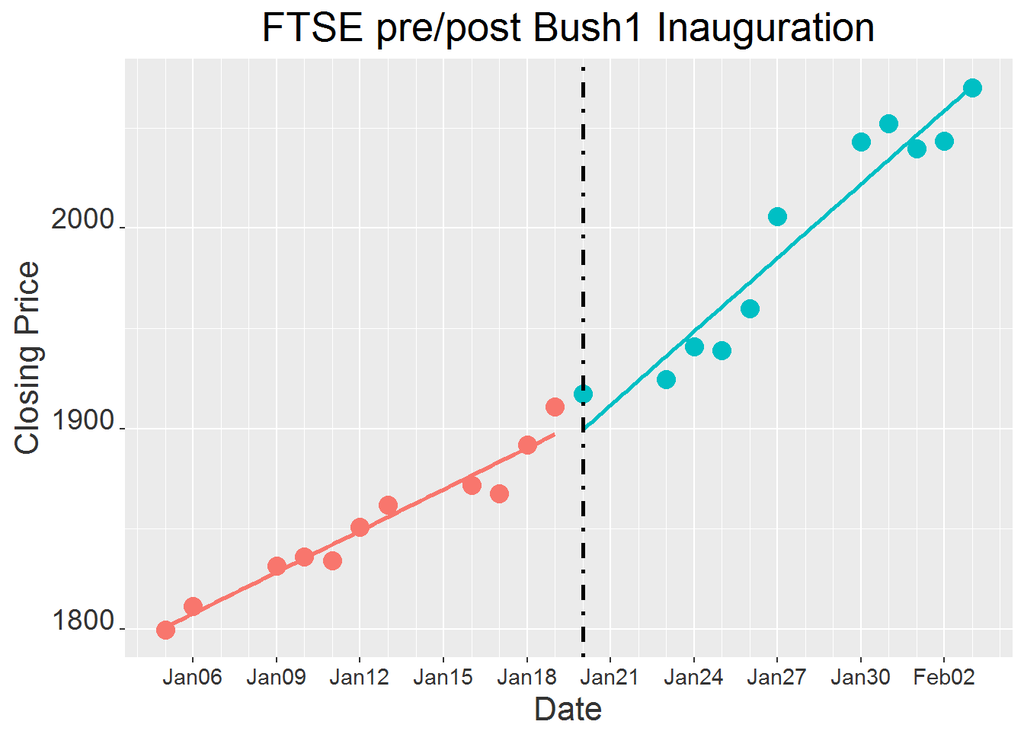

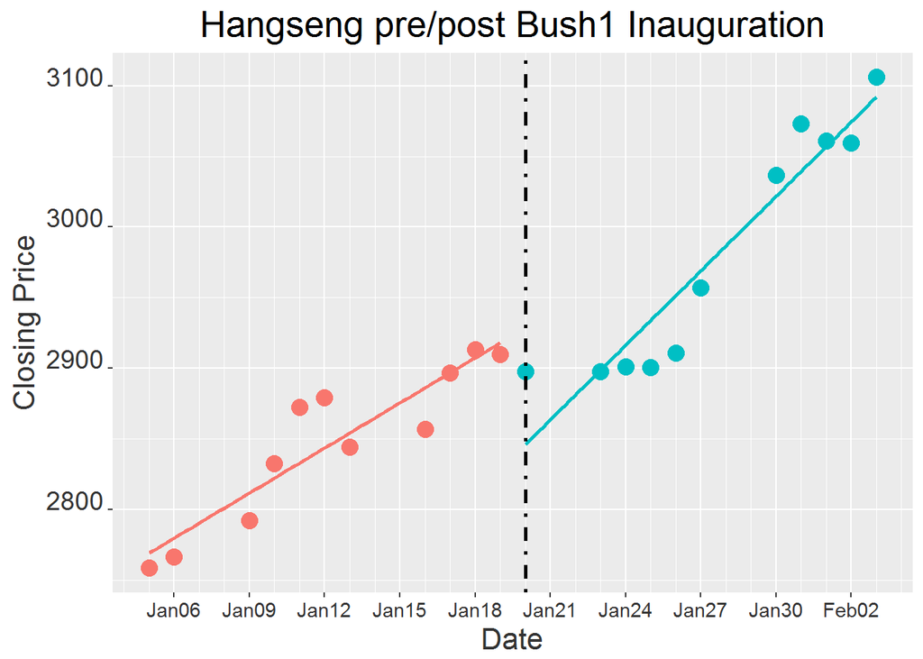

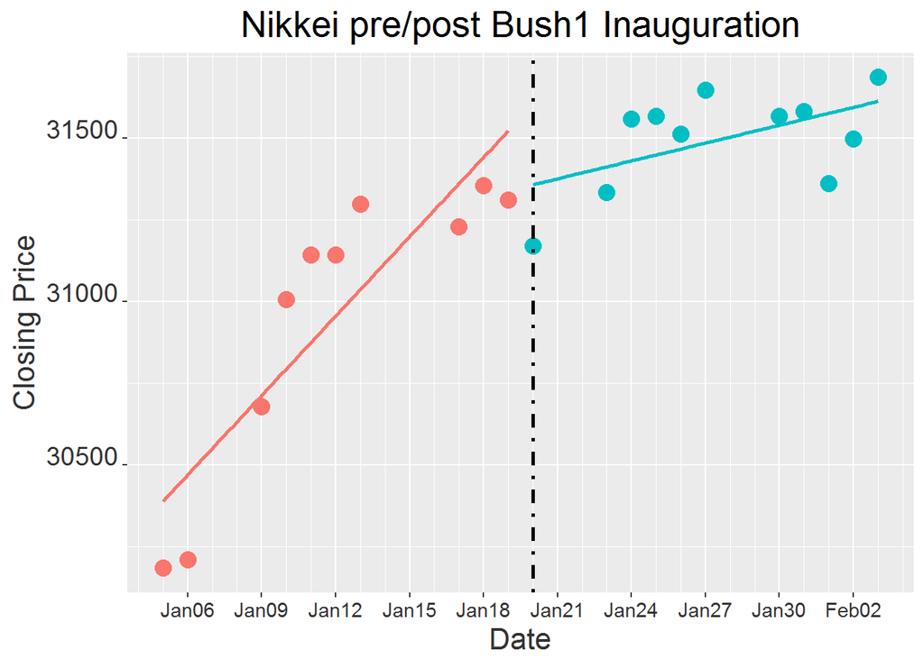

| President | id | Index | GradChange |
| --- | --- | --- | --- |
| GeorgeBush-1 | 1 | Dow Jones | 165.75% |
|  | 2 | S&P500 | 107.19% |
|  | 3 | Nasdaq | 206.52% |
|  | 4 | NYSE | 100.08% |
|  | 5 | FTSE | 78.06% |
|  | 6 | Hang Seng | 65.35% |
|  | 7 | Nikkei | -77.50% |

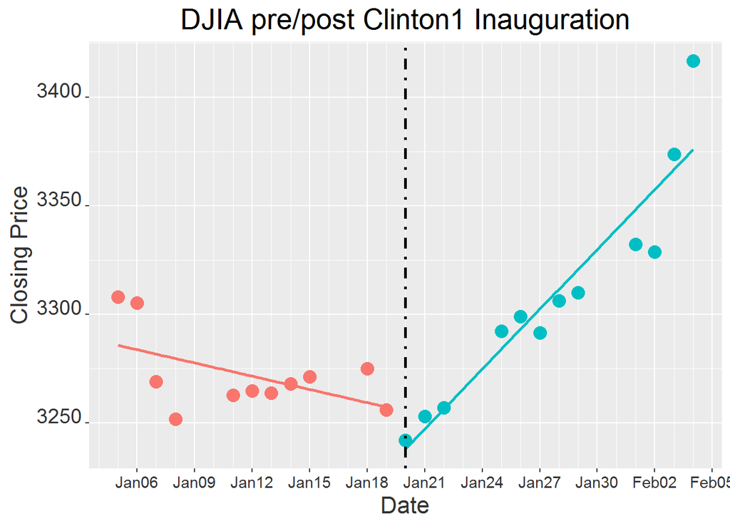

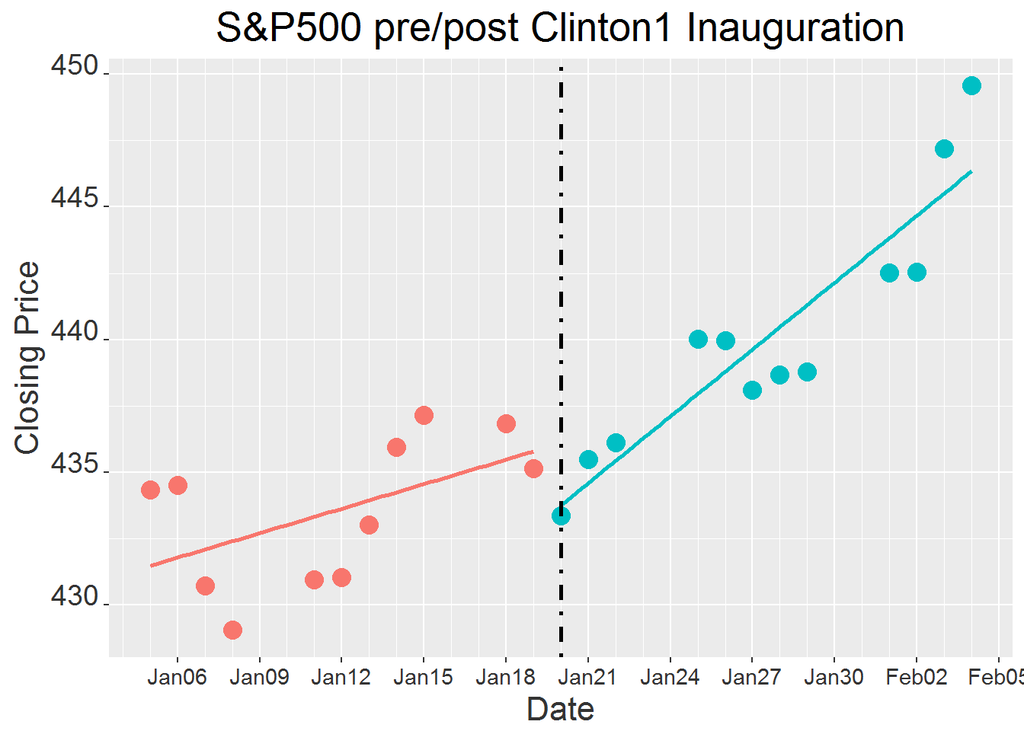

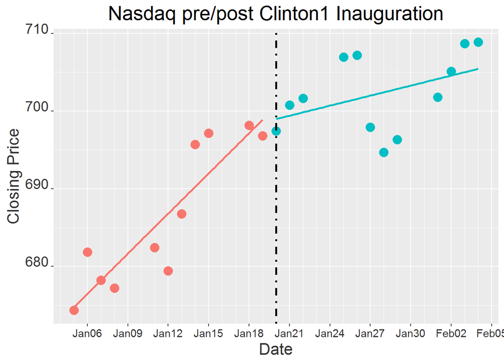